# CD34 Cell Line

Camilo Posso

09/27/2021

# Introduction

```r
restrict <- F

if (restrict) {
  samples <- sort(colSums(is.na(prot.mat)))[1:6] %>%
    names()
} else {
  samples <- sort(colSums(is.na(prot.mat))) %>%
    names()
}

prot.mat <- prot.mat[, samples]

colors.use <- colors.chosen[samples]

meta <- meta[rownames(meta) %in% samples, ]

## Filter out fully NA rows
idx <- rowSums(is.na(prot.mat)) == ncol(prot.mat)
prot.mat <- prot.mat[!idx, ]

## Creating MSnSet using the crosstab and metadata
m <- MSnSet(exprs = prot.mat, pData = meta[colnames(prot.mat), ])
```

```r
params.NA <- c(0.2, 0.4, 0.6)
params.pseudoNA <- c(0.1, 0.1, 0.1)
```

Below we have the metadata for this experiment. We have a total of 11 samples and 1058 Proteins. In this initial analysis we compare the `Pre` and `Post` groups, and investigate whether the imputation of the missing values is meaningful.

|  | PatientID | CellType | Trametinib | CellCount | Date |
| --- | --- | --- | --- | --- | --- |
| DIA_2C_Post_CD34 | 3585846 | CD34 | Post | 100000 | 18-Jun |
| DIA_5C_Post_CD34 | 3570806 | CD34 | Post | 97300 | 15-Jun |
| DIA_6A_Post_CD34 | 3577040 | CD34 | Post | 621000 | 24-Jun |
| DIA_9B_Post_CD34 | 3668110 | CD34 | Post | 23200 | 18-Jun |
| DIA_1F_Post_CD34_B | 3434172 | CD34 | Post | NaN | 28-Jun |
| DIA_1E_Pre_CD34_A | 3434172 | CD34 | Pre | 170000 | 15-Jun |
| DIA_2B_Pre_CD34 | 3585846 | CD34 | Pre | 66200 | 18-Jun |
| DIA_5B_Pre_CD34 | 3570806 | CD34 | Pre | 312000 | 15-Jun |
| DIA_6B_Pre_CD34 | 3577040 | CD34 | Pre | 111000 | 24-Jun |
| DIA_9A_Pre_CD34 | 3668110 | CD34 | Pre | 71900 | 18-Jun |
| DIA_1E_Pre_CD34_B | 3434172 | CD34 | Pre | NaN | 28-Jun |

$$\\[.2in]$$

# Missing data

First, notice the large amount of missing values present. Below we summarize the distribution of NA values in the data by counting the number of missing intensities per protein.

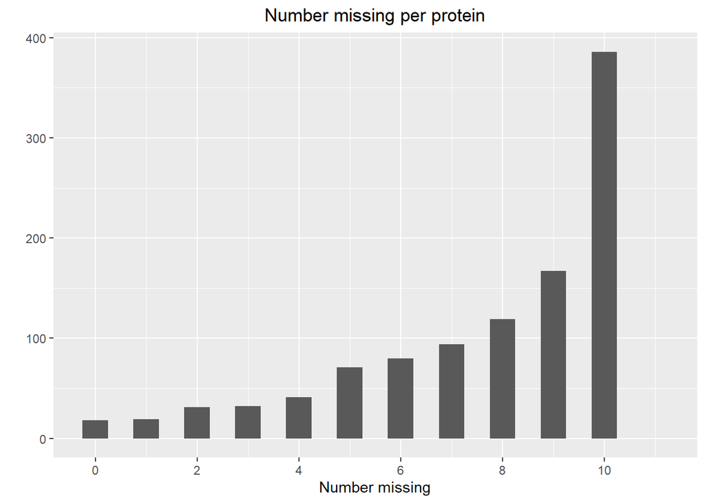

```r
p1
```

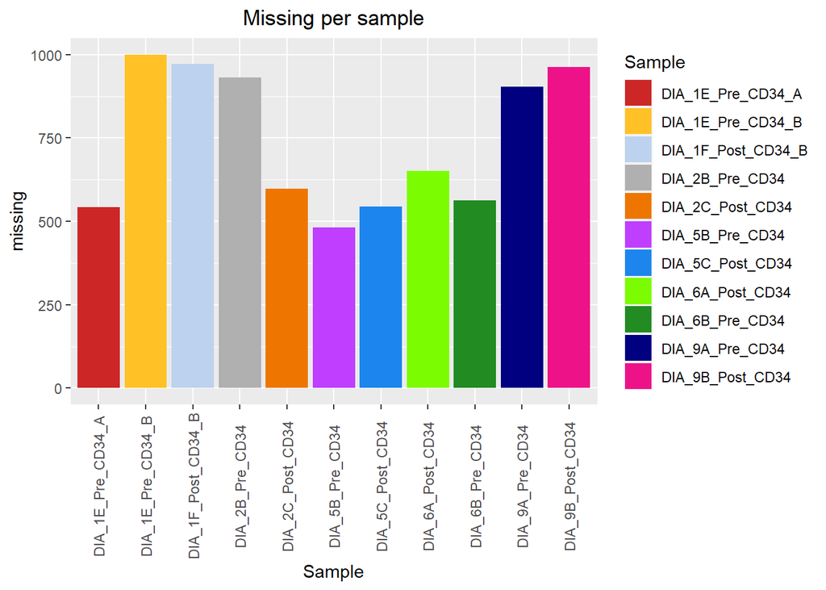

```r
p2
```

$$\\[.2in]$$